# Analysis of Crunchbase 2013 Snapshot

## Loading in data and preparing initial dataset

```python
import pandas as pd
import matplotlib
import seaborn as sns
import networkx as nx
import numpy as np
```

```python
%matplotlib inline
```

Next, **import into pandas dataframes.**

```python
objects = pd.read_csv("cb_objects.csv",sep=",", quotechar = "'",encoding = "ISO-8859-1")
people = pd.read_csv("cb_people.csv",sep=",", quotechar = "'",encoding = "ISO-8859-1")
relationships = pd.read_csv("cb_relationships.csv",sep=",", quotechar = "'",encoding = "ISO-8859-1")
degrees = pd.read_csv("cb_degrees.csv",sep=",", quotechar = "'",encoding = "ANSI")
```

**Drop investing firms** since we are not interested in that aspect of the data (for now).

```python
objects = objects[objects['entity_type'] == 'Company']
```

**Merge "people" and "objects" databases using "relationships" database.**

```python
data = objects.merge(relationships, left_on = 'id', right_on = 'relationship_object_id')
data = data.merge(people, left_on = 'person_object_id',right_on = 'object_id')
```

Keep only variables / data we are interested in.

```python
data.columns.tolist()
```

```
['id_x',
 'entity_type',
 'entity_id',
 'parent_id',
 'name',
 'normalized_name',
 'permalink',
 'category_code',
 'status',
 'founded_at',
 'closed_at',
 'domain',
 'homepage_url',
 'twitter_username',
 'logo_url',
 'logo_width',
 'logo_height',
 'short_description',
 'description',
 'overview',
 'tag_list',
 'country_code',
 'state_code',
 'city',
 'region',
 'first_investment_at',
 'last_investment_at',
 'investment_rounds',
 'investment_companies',
 'first_funding_at',
 'last_funding_at',
 'funding_rounds',
 'funding_total_USD',
 'first_milestone_at',
 'last_milestone_at',
 'milestones',
 'relationships',
 'created_by',
 'created_at_x',
 'updated_at_x',
 'id_y',
 'relationship_id',
 'person_object_id',
 'relationship_object_id',
 'start_at',
 'end_at',
 'is_past',
 'sequence',
 'title',
 'created_at_y',
 'updated_at_y',
 'id',
 'object_id',
 'first_name',
 'last_name',
 'birthplace',
 'affiliation_name']
```

```python
data = data[['person_object_id','id_x','name','title','start_at','end_at','first_name','last_name','category_code','short_description','description','founded_at','country_code','state_code','city','region','relationships','normalized_name']]
#del [objects,people,relationships,degrees]
```

**Sort table and display first 5 rows** just for some visualization of where we are.

```python
data.sort_values(by = ['person_object_id','founded_at'],ascending=[True,False],inplace=True)
data.head()
```

|  | person_object_id | id_x | name | title | start_at | end_at | first_name | last_name | category_code | short_description | description | founded_at | country_code | state_code | city | region | relationships | normalized_name |
| --- | --- | --- | --- | --- | --- | --- | --- | --- | --- | --- | --- | --- | --- | --- | --- | --- | --- | --- |
| 327696 | p:10 | c:5 | Facebook | Founder and CEO, Board Of Directors | NaN | NaN | Mark | Zuckerberg | social | Facebook is an online social networking servic... | Social network | 2004-02-01 | USA | CA | Menlo Park | SF Bay | 269 | facebook |
| 284551 | p:100 | c:27 | Plaxo | VP Business Development | NaN | NaN | Peter | Lester | web | NaN | Contact Management | 2002-11-17 | USA | CA | Sunnyvale | SF Bay | 27 | plaxo |
| 298929 | p:1000 | c:292 | Droplet Technology | CTO | NaN | NaN | Dr. Steven | E. Saunders | games_video | NaN | NaN | NaN | USA | CA | Menlo Park | SF Bay | 3 | droplet technology |
| 31537 | p:10000 | c:12007 | Sailthru | CEO & Founder | NaN | NaN | Neil | Capel | public_relations | Sailthru provides personalized marketing commu... | Customer Data & Communication Platform | 2008-06-01 | USA | NY | New York | New York | 18 | sailthru |
| 31541 | p:10000 | c:29676 | Belgrave Trust | Advisor | NaN | NaN | Neil | Capel | ecommerce | NaN | Carbon Offset Service | 2008-04-01 | USA | NY | New York | New York | 6 | belgrave trust |

## Preliminary visualization of data

Let's do some basic analysis first. I want a nice visualization of how the dataset breaks down into **industries** .

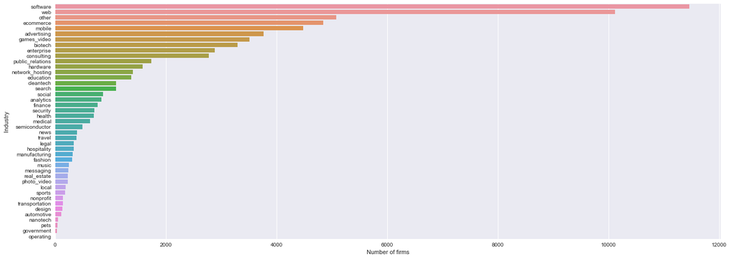

```python
industry_counts = data.groupby('category_code').id_x.apply(lambda x: len(x.unique()))

# Now force it to be a DataFrame...this is inelegant but it's the best I know how to do.
industry_counts = pd.DataFrame(industry_counts)
industry_counts.rename(columns = {'id_x':'count'}, inplace =True)
industry_counts.sort_values('count',ascending = False,inplace = True)

matplotlib.rcParams['figure.figsize'] = 22,8
ax = sns.barplot(x='count',y='category_code',data=industry_counts.reset_index())
ax.set(xlabel = 'Number of firms',ylabel = 'Industry')
```

We can do similar things to understand the geographical distribution of the data. First, let's look at **countries** :

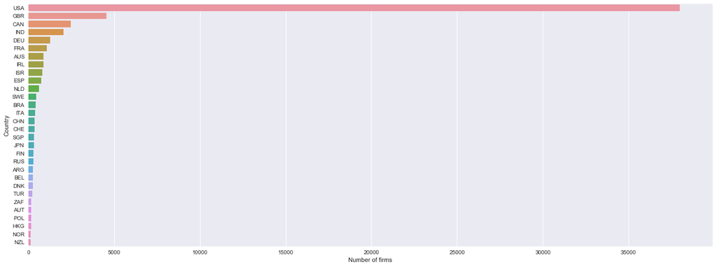

```python
country_counts = data.groupby('country_code').id_x.apply(lambda x: len(x.unique()))

# Now force it to be a DataFrame...this is inelegant but it's the best I know how to do.
country_counts = pd.DataFrame(country_counts)
country_counts.rename(columns = {'id_x':'count'}, inplace =True)
country_counts.sort_values('count',ascending = False,inplace = True)

matplotlib.rcParams['figure.figsize'] = 22,8
ax = sns.barplot(x='count',y='country_code',data=country_counts[0:30].reset_index())
ax.set(xlabel = 'Number of firms',ylabel = 'Country')
```

We can see that **the dataset is dominated by American firms** , followed by the UK and Canada. This makese sense, since it is an English-language website. Also, this is not a problem for my analysis, since I am focusing on the U.S. economy in my study.

Let's see what the breakdown is across states.

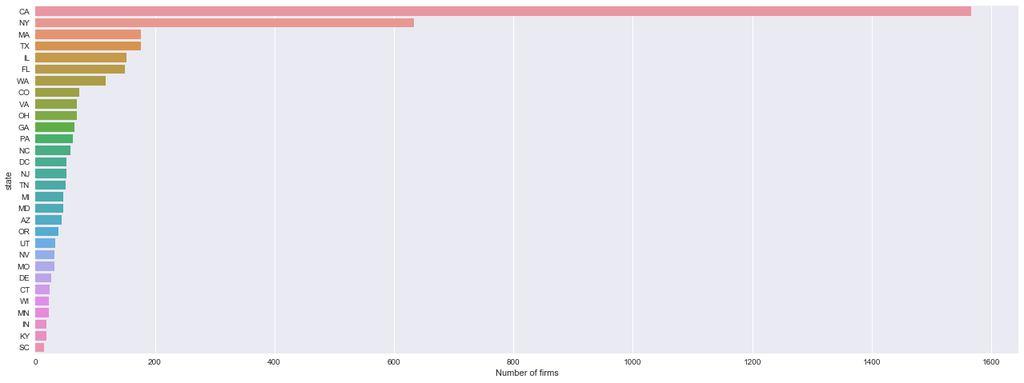

```python
state_counts = data[data['founded_at'] >= '2012-01-01'].groupby('state_code').id_x.apply(lambda x: len(x.unique()))

# Now force it to be a DataFrame...this is inelegant but it's the best I know how to do.
state_counts = pd.DataFrame(state_counts)
state_counts.rename(columns = {'id_x':'count'}, inplace =True)
state_counts.sort_values('count',ascending = False,inplace = True)

matplotlib.rcParams['figure.figsize'] = 22,8
ax = sns.barplot(x='count',y='state_code',data=state_counts[0:30].reset_index())
ax.set(xlabel = 'Number of firms',ylabel = 'state')
```

The bar plot above shows that the firms in the dataset are concentrated in **California, New York, and Massachusetts** , which is what we expected. Let's do one more check, to get a sense of how concentrated the dataset is once we normalize by population (mostly as practice with pandas). To do this, we need to import two new datasets: one dataset which has state names and populations, and another which has state names and codes.

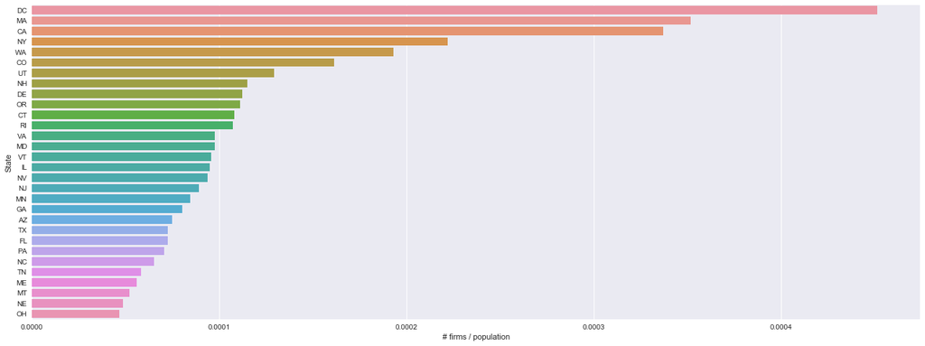

```python
statecodes = pd.read_csv('statecodes.csv').set_index('STATE_NAME')
state_pops = pd.read_csv('statepops.csv').set_index('STATE_NAME')

state_pops = state_pops.join(statecodes)
state_pops = state_pops.set_index('STUSAB')[['POPULATION']]

state_counts = state_counts.join(state_pops)
state_counts['normalized_count'] = state_counts['count'] / state_counts['POPULATION']
state_counts.sort_values('normalized_count',ascending=False,inplace=True)

matplotlib.rcParams['figure.figsize'] = 22,8
ax = sns.barplot(x='normalized_count',y='state_code',data=state_counts.reset_index()[0:30])
ax.set(xlabel = '# firms / population',ylabel = 'State')
```

TX is no longer near the top, and now MA and DC have passed CA. NY is 4th, followed by WA, CO and UT. While this is an admittedly rough measure of start-up activity (# of firms per resident), it definitely calls into question the narrative that California's economy is more conducive to start-up activity than that of MA. Of course, *to the extent that California's population is large due to its startup-friendly legal environment* this is not evidence against this hypothesis.

Let's do one more check: the same picture but restricted to companies that were founded after, say, 2005.

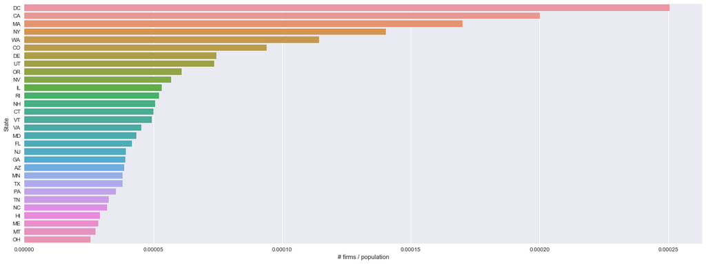

```python
state_counts = data[data['founded_at'] >= '2005-01-01'].groupby('state_code').id_x.apply(lambda x: len(x.unique()))
state_counts = pd.DataFrame(state_counts)
state_counts.rename(columns = {'id_x':'count'}, inplace =True)
state_counts.sort_values('count',ascending = False,inplace = True)
state_counts.head()

state_counts = state_counts.join(state_pops)
state_counts['normalized_count'] = state_counts['count'] / state_counts['POPULATION']
state_counts.sort_values('normalized_count',ascending=False,inplace=True)

matplotlib.rcParams['figure.figsize'] = 22,8
ax = sns.barplot(x='normalized_count',y='state_code',data=state_counts.reset_index()[0:30])
ax.set(xlabel = '# firms / population',ylabel = 'State')
```

Now let's get a sense of the coverage across time - let's make a **histogram of firm founding dates.**

```python
#founded = pd.to_datetime(data.founded_at)

#data.curr_firm_id.unique()

data.rename(columns = {"id_x":"curr_firm_id"},inplace = True)

firmIDs = pd.DataFrame(data.curr_firm_id.unique())
firmIDs.rename(columns = {0:"curr_firm_id"}, inplace = True)
#firmIDs.head()
foundingdates = data[['curr_firm_id','founded_at']].merge(firmIDs, how = 'left', left_on = 'curr_firm_id', right_on = 'curr_firm_id')
foundingdates['founded_at'] = pd.to_datetime(foundingdates['founded_at'])
foundingdates['founded_at'] = foundingdates['founded_at'].apply(lambda x: x.year)
foundingdates.sort_values('founded_at',ascending = False,inplace = True)

#sns.distplot(foundingdates)

#sns.distplot(foundingdates['founded_at'])
```

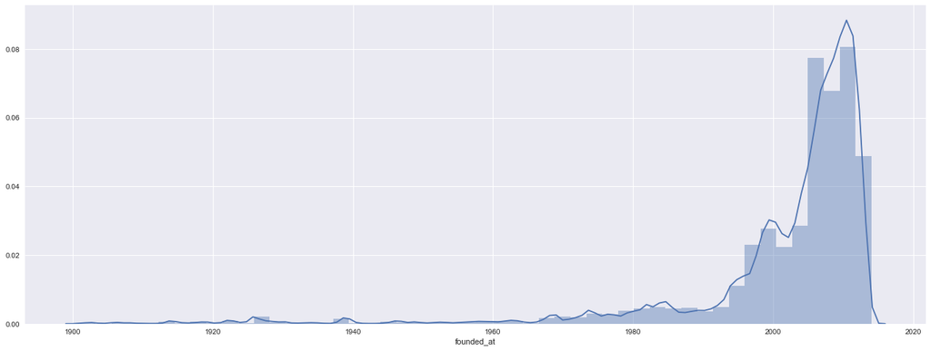

```python
matplotlib.rcParams['figure.figsize'] = 22,8
sns.distplot(foundingdates['founded_at'].dropna(axis = 0))
```

Now we can see that the coverage of the dataset is *heavily skewed towards recently founded companies.* Here is the cumulative distribution plot, for reference:

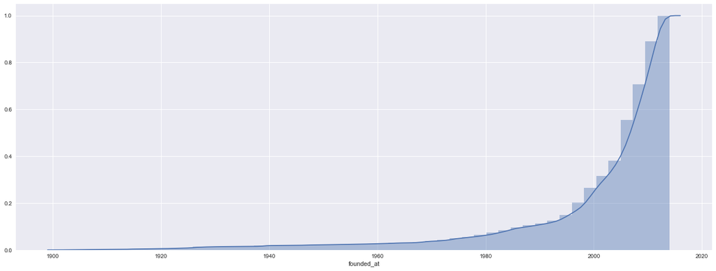

```python
sns.distplot(foundingdates['founded_at'].dropna(axis = 0), hist_kws=dict(cumulative = True), kde_kws = dict(cumulative=True))
```

## Main analysis: cataloguing spinoffs

### Preparing dataset

Now that we have our data ready, we are ready to analyze the connections between companies in our dataset. I will use the package `Networkx`, which **impelements graphs in Python.** To be able to build the graph, we need to have the data organized in such a way that I can easily check whether two firm id's are related by a worker flow. The simplest way to do this is to do a `groupby` on the key `person_object_id`, and then use `transform` and `join` back into the original dataset, to add a column that has the same values as `curr_firm_id`, but shifted forward one.

```python
data = objects.merge(relationships, left_on = 'id', right_on = 'relationship_object_id')
data = data.merge(people, left_on = 'person_object_id',right_on = 'object_id')
data = data[['person_object_id','id_x','name','title','start_at','end_at','first_name','last_name','category_code','short_description','description','founded_at','country_code','state_code','city','region','relationships','normalized_name']]


data.sort_values(['person_object_id','start_at'], ascending = [True,True], inplace=True)
data.rename(columns = {'id_x' : 'curr_firm_id'} , inplace=True)
data = data[['person_object_id','curr_firm_id','name','title','founded_at','start_at','first_name','last_name','category_code','state_code']]


# BTW, no idea why it won't let me do this all in one line...
data[['previous_firm_id','previous_state_code']] = data.groupby('person_object_id')['curr_firm_id','state_code'].shift(1)
data['previous_category_code'] = data.groupby('person_object_id')['category_code'].shift(1)
data.rename(columns = {"state_code": "curr_state_code","category_code":"curr_category_code"}, inplace = True)
data.to_pickle('data.pkl')
```

```python
data = pd.read_pickle('data.pkl')
data.head(50)
```

|  | person_object_id | curr_firm_id | name | title | founded_at | start_at | first_name | last_name | curr_category_code | curr_state_code | previous_firm_id | previous_state_code | previous_category_code |
| --- | --- | --- | --- | --- | --- | --- | --- | --- | --- | --- | --- | --- | --- |
| 327696 | p:10 | c:5 | Facebook | Founder and CEO, Board Of Directors | 2004-02-01 | NaN | Mark | Zuckerberg | social | CA | NaN | NaN | NaN |
| 284551 | p:100 | c:27 | Plaxo | VP Business Development | 2002-11-17 | NaN | Peter | Lester | web | CA | NaN | NaN | NaN |
| 298929 | p:1000 | c:292 | Droplet Technology | CTO | NaN | NaN | Dr. Steven | E. Saunders | games_video | CA | NaN | NaN | NaN |
| 31539 | p:10000 | c:2295 | aSmallWorld | CTO | 2004-03-01 | 2010-06-01 | Neil | Capel | web | NY | NaN | NaN | NaN |
| 31537 | p:10000 | c:12007 | Sailthru | CEO & Founder | 2008-06-01 | NaN | Neil | Capel | public_relations | NY | c:2295 | NY | web |
| 31538 | p:10000 | c:12043 | Money Media | CTO | NaN | NaN | Neil | Capel | NaN | NaN | c:12007 | NY | public_relations |
| 31540 | p:10000 | c:2526 | Music Nation | CTO | NaN | NaN | Neil | Capel | web | NaN | c:12043 | NaN | NaN |
| 31541 | p:10000 | c:29676 | Belgrave Trust | Advisor | 2008-04-01 | NaN | Neil | Capel | ecommerce | NY | c:2526 | NaN | web |
| 358611 | p:100000 | c:81556 | Island Yarn Boutique | Owner | 2003-01-01 | 2003-01-01 | Sue | Pilsch | other | MD | NaN | NaN | NaN |
| 347155 | p:100002 | c:68561 | APAX Software | Lead Project Manager | NaN | NaN | Keith | Kurzendoerfer | software | KY | NaN | NaN | NaN |
| 358614 | p:100006 | c:81558 | CareerEncore | CEO & Principal Recruiter | 2006-01-01 | 2006-01-01 | Courtney | Homer | other | NaN | NaN | NaN | NaN |
| 100626 | p:100009 | c:152329 | CherryPick | Co-Founder | NaN | 2012-01-01 | Eddy | Badrina | NaN | TX | NaN | NaN | NaN |
| 100627 | p:100009 | c:81559 | BuzzShift | CSO and Co-Founder | 2010-05-01 | NaN | Eddy | Badrina | consulting | TX | c:152329 | TX | NaN |
| 319667 | p:100011 | c:43604 | Junction Solutions | President and CEO | 2001-01-01 | NaN | Jeff | Grell | software | CO | NaN | NaN | NaN |
| 319668 | p:100012 | c:43604 | Junction Solutions | COO | 2001-01-01 | NaN | Nick | Bova | software | CO | NaN | NaN | NaN |
| 304203 | p:100013 | c:3246 | IBM | Various Management positions | NaN | NaN | Umesh | Singh | software | NY | NaN | NaN | NaN |
| 304204 | p:100013 | c:37664 | Vendavo | CFO | 2000-01-01 | NaN | Umesh | Singh | software | CA | c:3246 | NY | software |
| 304205 | p:100013 | c:43604 | Junction Solutions | CFO | 2001-01-01 | NaN | Umesh | Singh | software | CO | c:37664 | CA | software |
| 304206 | p:100013 | c:4823 | Ariba | Senior VP Finance | NaN | NaN | Umesh | Singh | software | CA | c:43604 | CO | software |
| 304207 | p:100013 | c:4849 | Aprimo | EVP & CFO | 1998-01-01 | NaN | Umesh | Singh | web | IN | c:4823 | CA | software |
| 358618 | p:100014 | c:81561 | ValveXchange | Chairman of the Board and CEO | NaN | NaN | Larry | Blankenship | hardware | CO | NaN | NaN | NaN |
| 358619 | p:100015 | c:81562 | CryoLife | Chairman, President and CEO | NaN | NaN | Steven | G. Anderson | hardware | GA | NaN | NaN | NaN |
| 358620 | p:100016 | c:81562 | CryoLife | Thomas F. Ackerman Executive Vice President an... | NaN | NaN | Thomas | F. Ackerman | hardware | GA | NaN | NaN | NaN |
| 205510 | p:100017 | c:81564 | SurgiQuest | Founder, CEO | 2006-05-01 | 2005-01-01 | Kurt | Azarbarzin | medical | CT | NaN | NaN | NaN |
| 205507 | p:100017 | c:201499 | U.S. Surgical/Tyco Healthcare | NaN | NaN | NaN | Kurt | Azarbarzin | NaN | NaN | c:81564 | CT | medical |
| 205508 | p:100017 | c:201500 | Respimetrix | NaN | NaN | NaN | Kurt | Azarbarzin | NaN | NaN | c:201499 | NaN | NaN |
| 205509 | p:100017 | c:67809 | Spine Wave | NaN | 2001-02-01 | NaN | Kurt | Azarbarzin | medical | CT | c:201500 | NaN | NaN |
| 89347 | p:100018 | c:50241 | Borderfree Inc | VP, Platform Integration | 1999-01-01 | 2008-06-01 | Adam | Beckerman | ecommerce | NY | NaN | NaN | NaN |
| 89348 | p:100018 | c:50241 | Borderfree Inc | VP, Product Management | 1999-01-01 | 2013-02-01 | Adam | Beckerman | ecommerce | NY | c:50241 | NY | ecommerce |
| 89346 | p:100018 | c:148554 | GovHub | NaN | 2011-01-01 | NaN | Adam | Beckerman | other | CA | c:50241 | NY | ecommerce |
| 4190 | p:100022 | c:101797 | Vehom | Owner | 2011-07-26 | 2011-07-26 | OÄuz KaÄan | Aslan | advertising | NaN | NaN | NaN | NaN |
| 358623 | p:100023 | c:81571 | Freevi | Freevi | NaN | NaN | Neil | Chandran | NaN | NaN | NaN | NaN | NaN |
| 297964 | p:100024 | c:287 | King.com | Chief Creative Head & Co-Founder | 2003-08-01 | 2003-02-01 | Sebastian | Knutsson | games_video | NaN | NaN | NaN | NaN |
| 297965 | p:100025 | c:287 | King.com | Co-founder & Head of System development | 2003-08-01 | 2003-02-01 | Thomas | Hartwig | games_video | NaN | NaN | NaN | NaN |
| 297966 | p:100026 | c:287 | King.com | Co-founder & Managing Director | 2003-08-01 | 2003-02-01 | Lars | Markgren | games_video | NaN | NaN | NaN | NaN |
| 355389 | p:100029 | c:77700 | Uber Bazaar | Co-Founder | 2010-12-19 | NaN | Kaushik | Prakash | ecommerce | NaN | NaN | NaN | NaN |
| 355390 | p:100030 | c:77700 | Uber Bazaar | Co-Founder | 2010-12-19 | NaN | Jai | Patel | ecommerce | NaN | NaN | NaN | NaN |
| 358624 | p:100031 | c:81576 | dotCORD | Managing Director | 2007-12-14 | 2007-12-14 | Sandeep | Hegde | software | NaN | NaN | NaN | NaN |
| 358625 | p:100031 | c:81577 | DigitalAvatar | Co-Founder | NaN | 2011-05-31 | Sandeep | Hegde | NaN | NaN | c:81576 | NaN | software |
| 358626 | p:100033 | c:81578 | PRoPR Agency | Founder/General Manager | 2006-01-01 | NaN | Ivet | Dobromirova | public_relations | NaN | NaN | NaN | NaN |
| 358629 | p:100035 | c:81580 | Rhinofile | Creator | 2006-01-01 | 2011-07-09 | Ross | Richards | software | NaN | NaN | NaN | NaN |
| 358630 | p:100036 | c:81582 | Junyu | NaN | NaN | NaN | Angela | Chu | NaN | NaN | NaN | NaN | NaN |
| 257939 | p:100046 | c:238425 | Cloudfind | Founder & CEO | 2010-01-01 | 2010-01-01 | Sebastian | Toke-Nichols | software | NaN | NaN | NaN | NaN |
| 257940 | p:100046 | c:81592 | TopicLogic | CEO | 2011-09-01 | 2010-09-01 | Sebastian | Toke-Nichols | software | NaN | c:238425 | NaN | software |
| 358634 | p:100047 | c:81592 | TopicLogic | COO | 2011-09-01 | 2010-09-01 | Peter | Briscoe | software | NaN | NaN | NaN | NaN |
| 356762 | p:100048 | c:79332 | Scratch Music Group | Co-Founder and CEO | 2002-01-01 | NaN | Rob | Principe | music | NY | NaN | NaN | NaN |
| 341843 | p:100049 | c:79332 | Scratch Music Group | COO | 2002-01-01 | 2004-11-01 | Mike | Cannady | music | NY | NaN | NaN | NaN |
| 341842 | p:100049 | c:63 | YouTube | Music Content and Strategic Partnerships | 2005-02-01 | 2012-11-01 | Mike | Cannady | games_video | CA | c:79332 | NY | music |
| 341844 | p:100049 | c:79332 | Scratch Music Group | Board Member | 2002-01-01 | 2012-11-01 | Mike | Cannady | music | NY | c:63 | CA | games_video |
| 356763 | p:100050 | c:79332 | Scratch Music Group | Chief Marketing Officer | 2002-01-01 | 2010-10-10 | Eva | Boker | music | NY | NaN | NaN | NaN |

### What fraction of observations have the information we want?

```python
fraction = data['start_at'].count() / len(data['start_at'])
print(fraction)
```

```
0.528615865273
```

We have start dates for about half of observations. How about which observations have *everything* we need?

```python
#fraction = data[['start_at','curr_category_code','curr_state_code']].count() / len(data['start_at'])
#data['complete_record'] = all(data[['start_at','curr_category_code','curr_state_code']].notnull(),axis = 1).astype(int)

#data['avail'] = all(data[['start_at']].notnull())
#fraction = data['Col_5'].sum()
#print(fraction)

data['available'] = np.where((data['start_at'].notnull() == True) & (data['curr_category_code'].notnull() == True) & (data['curr_state_code'].notnull() == True),1,0)
#data.head()

fraction = data['available'].sum() / len(data['available'])
print(fraction)
```

```
0.231067322581
```

### Constructing the graph using `Networkx`

```python
G0 = nx.DiGraph()
G0.add_nodes_from(data['curr_firm_id'].unique())
attributes = {id:name for id,name in zip(data.curr_firm_id,data.name)}
nx.set_node_attributes(G0,'name',attributes)

# Draw edge from firm 1 to firm 2 if: (Firm 2 was founded before Firm 1) AND (Someone in the dataset )
```

```python
# Restrict analysis to a particular state/industry sub-sample
data = data[(data['curr_category_code'] == 'biotech') & (data['state_code'] == 'WA')]

# Construct directed graph object
G0 = nx.DiGraph()

# Add nodes from the Numpy array
# data['curr_firm_id'].unique(), which
# lists each firm in the (restricted) dataset exactly once

G0.add_nodes_from(data['curr_firm_id'].unique())

# Add firm names as attributes (for later)
attributes = {id:name for id,name in zip(data.curr_firm_id,data.name)}
nx.set_node_attributes(G0,'name',attributes)

# Want to draw edge from firm 2 to firm 1 if
# (1) someone worked at 1 immediately prior to working at 2,
# and (2) both firms are in the same industry.
# We are already know that curr_category_code is the industry we are interested in,
# so we now simply need to drop observations where previous_category_code is
# not equal to curr_category_code. Then add an edge corresponding to each remaining
# observation.

data_sub = data[data['curr_category_code']==data['previous_category_code']]
pairs = data_sub[['curr_firm_id','previous_firm_id']]
pairs = pairs.dropna()
tuples = [tuple(x) for x in pairs.values]
G0.add_edges_from(tuples)
nx.write_gml(G0,'out.gml')
```

[output not shown]

[output cut: 16 more lines]

[output not shown]

Now we can compute the fraction of nodes which have an outward edge: that is, the fraction of firms in the state-industry pair with a "parent" firm (defined, for now, by at least one employee having worked there immediately prior) in the same state-industry pair. *NB: We have to change the analysis somewhat above to allow parent firms to be in different states.*

```python
t1=[n for n,k in G0.out_degree_iter() if k>=1]

len(t1) / len(G0.nodes())
```

```
0.471004243281471
```

```python
firms = data[['curr_firm_id','previous_firm_id']][0:10]
firms.head()
```

[output not shown]

First we want to create a graph encoding basic worker flow relationships: add edge pointing from firm A to firm B if someone worked at firm A before working at firm B.

First, let's see how good our data on start dates is: **what is the proportion of observations that are not missing?**

```python
data.start_at.count() / data.shape[0]
```

```
0.52861586527262017
```

How about if we restrict to American companies?

```python
data[data['country_code'] == 'USA'].start_at.count() / data[data['country_code'] == 'USA'].shape[0]
```

```
0.4887979633643405
```

That is, we have 49% of these data. How about data on the founding date of companies? Then we can just assume that everyone in this dataset is part of the founding team of companies. This gives us an overestimate, which is still useful, since I am trying to see if this happens a lot.

```python
data.founded_at.count() / data.shape[0]
```

```
0.64595146415994076
```

Better, but not great. However, we are counting all person-firm pairs; we only need one of these per firm to have its `founded_at` data. I will come back to this. First, let's see how the above statistic does when we restrict the sample to American companies.

```python
data[data['country_code'] == 'USA'].founded_at.count() / data[data['country_code'] == 'USA'].shape[0]
```

```
0.85502483636108129
```

We now have 85% of these data. Finally, let's see if there's any heterogeneity in the availability of these data across industries in the US.

```python
data_US = data[data['country_code'] == 'USA']

industry_coverage = data_US.groupby('category_code').start_at.count()
```